# IE2152 Statistics for IE Project Final Project

```r
"FOR DEFENCE"
```

```
## [1] "FOR DEFENCE"
```

```r
#for defining model
model1.4 <- lm(data_22$GNP~data_22$D); model1.4
```

```
##
## Call:
## lm(formula = data_22$GNP ~ data_22$D)
##
## Coefficients:
##  (Intercept)     data_22$D
## -159406019.1          44.2
```

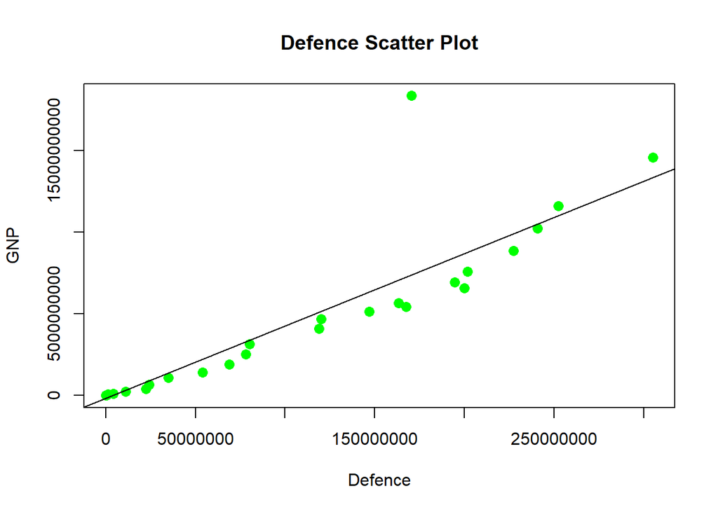

```r
#for plotting
plot(data_22$D,data_22$GNP, pch = 16, cex = 1.3, col = "green", main = "Defence Scatter Plot", xlab = "Defence", ylab = "GNP")
abline(model1.4$coefficients)
```

```r
#Create the multiple regression model for GNP, CE and D.
model1<-lm(y~x1+x4); model1
```

```
##
## Call:
## lm(formula = y ~ x1 + x4)
##
## Coefficients:
##   (Intercept)             x1             x4
## -110211313.75           8.92         -17.04
```

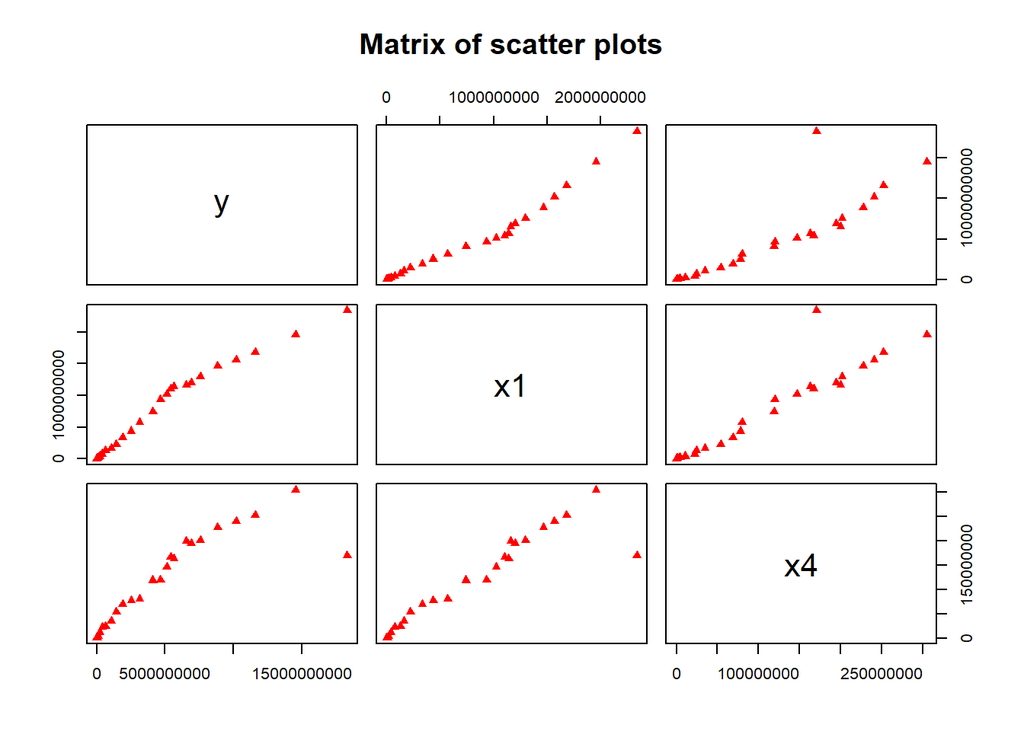

```r
#Obtain the scatter plot matrix.
pairs(y~x1+x4,pch=17,col='red',main='Matrix of scatter plots')
```

```r
#Create the multiple regression model.
model1<-lm(y~x1+x4,); model1
```

```
##
## Call:
## lm(formula = y ~ x1 + x4)
##
## Coefficients:
##   (Intercept)             x1             x4
## -110211313.75           8.92         -17.04
```

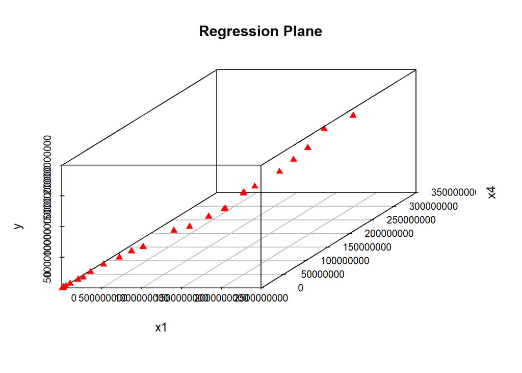

```r
#Plot the regression plane on the 3D scatter diagram.
G<-scatterplot3d(x1,x4, y, pch=17, color='red', main ="Regression Plane")
```

…

#### 3.3.2.2. Hypothesis Tests on the Slope and Intercept

We conducted Hypothesis test on slope and intercept for each variable in two tail test type. Then results are compared with critical value and decision is given about rejected or not …

```r
# FOR GNP DEPENDENT MULTIPLE
summary(model1); anova(model1)
```

```
##
## Call:
## lm(formula = y ~ x1 + x4)
##
## Residuals:
##         Min          1Q      Median          3Q         Max
## -1628158802    34647222   110187782   110219462  2406578750
##
## Coefficients:
##                  Estimate    Std. Error t value             Pr(>|t|)
## (Intercept) -110211313.75  131108104.95   -0.84                 0.41
## x1                   8.92          0.54   16.52 < 0.0000000000000002 ***
## x4                 -17.04          3.88   -4.39             0.000085 ***
## ---
## Signif. codes:  0 '***' 0.001 '**' 0.01 '*' 0.05 '.' 0.1 ' ' 1
##
## Residual standard error: 676000000 on 39 degrees of freedom
## Multiple R-squared:  0.978,  Adjusted R-squared:  0.977
## F-statistic:  871 on 2 and 39 DF,  p-value: <0.0000000000000002
```

|  | Df | Sum Sq | Mean Sq | F value | Pr(>F) |
| --- | --- | --- | --- | --- | --- |
| x1 | 1 | 787045294150890029046 | 787045294150890029046 | 1723.30 | 0.0000000000000000000000000000000006846 |
| x4 | 1 | 8786389339684835328 | 8786389339684835328 | 19.24 | 0.0000849007695636894832783014841481872 |
| Residuals | 39 | 17811644388137398272 | 456708830465061504 | NA | NA |

```r
#FOR HYPOTHESIS ON HO:B(0,1)=0 AND H1:B(0,1)=1  WITH ALPHA 0.01 F AND T VALUES ARE COMPARISED

 n <- 42
"T TEST FOR ALPHA: 0.01"
```

```
## [1] "T TEST FOR ALPHA: 0.01"
```

```r
tc <- qt(0.01/2,n-2,lower=F); tc
```

```
## [1] 2.704
```

```r
"FOR CURRENT EXPENDITURES"
```

```
## [1] "FOR CURRENT EXPENDITURES"
```

```r
#for obtaining information about model
summary(model1.1); anova(model1.1)
```

```
##
## Call:
## lm(formula = data_22$GNP ~ data_22$CE)
##
## Residuals:
##         Min          1Q      Median          3Q         Max
## -1716821872  -141932638   221073922   226161251  2972457859
##
## Coefficients:
##                   Estimate     Std. Error t value            Pr(>|t|)
## (Intercept) -226165666.996  154949927.732   -1.46                0.15
## data_22$CE           6.660          0.194   34.40 <0.0000000000000002 ***
## ---
## Signif. codes:  0 '***' 0.001 '**' 0.01 '*' 0.05 '.' 0.1 ' ' 1
##
## Residual standard error: 815000000 on 40 degrees of freedom
## Multiple R-squared:  0.967,  Adjusted R-squared:  0.966
## F-statistic: 1.18e+03 on 1 and 40 DF,  p-value: <0.0000000000000002
```

|  | Df | Sum Sq | Mean Sq | F value | Pr(>F) |
| --- | --- | --- | --- | --- | --- |
| data_22$CE | 1 | 787045294150890029046 | 787045294150890029046 | 1184 | 0.0000000000000000000000000000002474 |
| Residuals | 40 | 26598033727822225408 | 664950843195555584 | NA | NA |

```r
"FOR PERSONNEL EXPENDITURES"
```

```
## [1] "FOR PERSONNEL EXPENDITURES"
```

```r
#for obtaining information about model
summary(model1.2); anova(model1.2)
```

```
##
## Call:
## lm(formula = data_22$GNP ~ data_22$PE)
##
## Residuals:
##         Min          1Q      Median          3Q         Max
## -1753921283  -189086051   223190424   229625212  3030704428
##
## Coefficients:
##                  Estimate    Std. Error t value            Pr(>|t|)
## (Intercept) -229627474.88  155176339.81   -1.48                0.15
## data_22$PE           7.90          0.23   34.37 <0.0000000000000002 ***
## ---
## Signif. codes:  0 '***' 0.001 '**' 0.01 '*' 0.05 '.' 0.1 ' ' 1
##
## Residual standard error: 816000000 on 40 degrees of freedom
## Multiple R-squared:  0.967,  Adjusted R-squared:  0.966
## F-statistic: 1.18e+03 on 1 and 40 DF,  p-value: <0.0000000000000002
```

|  | Df | Sum Sq | Mean Sq | F value | Pr(>F) |
| --- | --- | --- | --- | --- | --- |
| data_22$PE | 1 | 786988380344163106806 | 786988380344163106806 | 1181 | 0.0000000000000000000000000000002582 |
| Residuals | 40 | 26654947534549295104 | 666373688363732352 | NA | NA |

```r
"FOR OTHER CURRENT EXPENDITURES"
```

```
## [1] "FOR OTHER CURRENT EXPENDITURES"
```

```r
#for obtaining information about model
summary(model1.3); anova(model1.3)
```

```
##
## Call:
## lm(formula = data_22$GNP ~ data_22$OCE)
##
## Residuals:
##         Min          1Q      Median          3Q         Max
## -2577727888    68594453   194096010   194158028  2716212037
##
## Coefficients:
##                 Estimate   Std. Error t value            Pr(>|t|)
## (Intercept) -194110949.5  163359824.9   -1.19                0.24
## data_22$OCE         42.2          1.3   32.48 <0.0000000000000002 ***
## ---
## Signif. codes:  0 '***' 0.001 '**' 0.01 '*' 0.05 '.' 0.1 ' ' 1
##
## Residual standard error: 862000000 on 40 degrees of freedom
## Multiple R-squared:  0.963,  Adjusted R-squared:  0.963
## F-statistic: 1.05e+03 on 1 and 40 DF,  p-value: <0.0000000000000002
```

|  | Df | Sum Sq | Mean Sq | F value | Pr(>F) |
| --- | --- | --- | --- | --- | --- |
| data_22$OCE | 1 | 783911783171596746722 | 783911783171596746722 | 1055 | 0.000000000000000000000000000002299 |
| Residuals | 40 | 29731544707115229184 | 743288617677880704 | NA | NA |

```r
"FOR DEFENCE"
```

```
## [1] "FOR DEFENCE"
```

```r
#for obtaining information about model
summary(model1.4); anova(model1.4)
```

```
##
## Call:
## lm(formula = data_22$GNP ~ data_22$D)
##
## Residuals:
##         Min          1Q      Median          3Q         Max
## -2129157701  -698222699   159377216   159579281 10950798126
##
## Coefficients:
##                  Estimate    Std. Error t value            Pr(>|t|)
## (Intercept) -159406019.08  366042448.64   -0.44                0.67
## data_22$D           44.24          3.22   13.73 <0.0000000000000002 ***
## ---
## Signif. codes:  0 '***' 0.001 '**' 0.01 '*' 0.05 '.' 0.1 ' ' 1
##
## Residual standard error: 1890000000 on 40 degrees of freedom
## Multiple R-squared:  0.825,  Adjusted R-squared:  0.821
## F-statistic:  188 on 1 and 40 DF,  p-value: <0.0000000000000002
```

|  | Df | Sum Sq | Mean Sq | F value | Pr(>F) |
| --- | --- | --- | --- | --- | --- |
| data_22$D | 1 | 671172057876774387722 | 671172057876774387722 | 188.4 | 0.0000000000000001009 |
| Residuals | 40 | 142471270001937809418 | 3561781750048445440 | NA | NA |

…

#### 3.3.2.3. Confidence Intervals for the Slope and Intercept

The slope representing the relationship of Y with X, and a 95% confidence interval for the x value were calculated and examined whether it excluded 0. If it does not contain 0, we can conclude that there is a significant linear relationship between X and Y. …

```r
#We can find the 95% CI for the intercept and slopes as follows:
confint(model1.1, level=0.95)
```

```
##                      2.5 %       97.5 %
## (Intercept) -539331152.664 86999818.672
## data_22$CE           6.269        7.051
```

```r
confint(model1.2, level=0.95)
```

```
##                      2.5 %       97.5 %
## (Intercept) -543250556.415 83995606.660
## data_22$PE           7.438        8.367
```

```r
confint(model1.3, level=0.95)
```

```
##                     2.5 %       97.5 %
## (Intercept) -524273471.43 136051572.50
## data_22$OCE         39.54        44.78
```

```r
confint(model1.4, level=0.95)
```

```
##                     2.5 %       97.5 %
## (Intercept) -899205403.83 580393365.66
## data_22$D           37.73        50.76
```

```r
#FOR MULTIPLE
confint(model1)
```

```
##                      2.5 %        97.5 %
## (Intercept) -375402487.186 154979859.683
## x1                   7.829        10.014
## x4                 -24.896        -9.181
```

…

#### 3.3.2.4. Analysis of Sum of Squares and Mean Squares

The sum of squares represents a measure of variation or deviation from the mean. It is calculated as a summation of the squares of the differences from the mean. The calculation of the total sum of squares considers both the sum of squares from the factors and from randomness or error and also we calculated R squared value and table form is established …

```r
n<-42
"FOR CURRENT EXPENDITURES"
```

```
## [1] "FOR CURRENT EXPENDITURES"
```

```r
#for Sum of Squares analysis SST,SSR,SSE are Calculated
xbar.g<- mean(data_22$GNP)
sst.ce <- sum((data_22$GNP-xbar.g)^2); sst.ce
```

```
## [1] 813643327878712262646
```

```r
ssr.ce <- sum((model1.1$fitted.values-xbar.g)^2); ssr.ce
```

```
## [1] 787045294150890029046
```

```r
sse.ce <- sum(model1.1$residuals^2); sse.ce
```

```
## [1] 26598033727822225408
```

```r
f0 <- (ssr.ce/1)/(sse.ce/(n-2)); f0
```

```
## [1] 1184
```

```r
#for Mean Squares MSR,MSE are calculated
msr.ce <- anova(model1.1)$`Mean Sq`[1]
mse.ce <- anova(model1.1)$`Mean Sq`[2]
#R square is calculated
rsq.ce <- ssr.ce/sst.ce; rsq.ce
```

```
## [1] 0.9673
```

```r
#for table form
cbind(ssr.ce,sse.ce,sst.ce,msr.ce,mse.ce,rsq.ce)
```

```
##                     ssr.ce               sse.ce                sst.ce
## [1,] 787045294150890029046 26598033727822225408 813643327878712262646
##                     msr.ce             mse.ce rsq.ce
## [1,] 787045294150890029046 664950843195555584 0.9673
```

```r
"FOR PERSONNEL EXPENDITURES"
```

```
## [1] "FOR PERSONNEL EXPENDITURES"
```

```r
#for Sum of Squares analysis SST,SSR,SSE are Calculated
sst.pe <- sum((data_22$GNP-xbar.g)^2); sst.pe
```

```
## [1] 813643327878712262646
```

```r
ssr.pe <- sum((model1.2$fitted.values-xbar.g)^2); ssr.pe
```

```
## [1] 786988380344162975764
```

```r
sse.pe <- sum(model1.2$residuals^2); sse.pe
```

```
## [1] 26654947534549295104
```

```r
f1 <- (ssr.pe/1)/(sse.pe/(n-2)); f1
```

```
## [1] 1181
```

```r
#for Mean Squares MSR,MSE are calculated
msr.pe <- anova(model1.2)$`Mean Sq`[1]
mse.pe <- anova(model1.2)$`Mean Sq`[2]

#R square is calculated
rsq.pe <- ssr.pe/sst.pe; rsq.pe
```

```
## [1] 0.9672
```

```r
#for table form
cbind(ssr.pe,sse.pe,sst.pe,msr.pe,mse.pe,rsq.pe)
```

```
##                     ssr.pe               sse.pe                sst.pe
## [1,] 786988380344162975764 26654947534549295104 813643327878712262646
##                     msr.pe             mse.pe rsq.pe
## [1,] 786988380344163106806 666373688363732352 0.9672
```

```r
"FOR OTHER CURRENT EXPENDITURES"
```

```
## [1] "FOR OTHER CURRENT EXPENDITURES"
```

```r
#for Sum of Squares analysis SST,SSR,SSE are Calculated
sst.oce <- sum((data_22$GNP-xbar.g)^2); sst.oce
```

```
## [1] 813643327878712262646
```

```r
ssr.oce <- sum((model1.3$fitted.values-xbar.g)^2); ssr.oce
```

```
## [1] 783911783171597008986
```

```r
sse.oce <- sum(model1.3$residuals^2); sse.oce
```

```
## [1] 29731544707115229184
```

```r
f2 <- (ssr.oce/1)/(sse.oce/(n-2)); f2
```

```
## [1] 1055
```

```r
#for Mean Squares MSR,MSE are calculated
msr.oce <- anova(model1.3)$`Mean Sq`[1]
mse.oce <- anova(model1.3)$`Mean Sq`[2]

#R square is calculated
rsq.oce <- ssr.oce/sst.oce; rsq.oce
```

```
## [1] 0.9635
```

```r
#for table form
cbind(ssr.oce,sse.oce,sst.oce,msr.oce,mse.oce,rsq.oce)
```

```
##                    ssr.oce              sse.oce               sst.oce
## [1,] 783911783171597008986 29731544707115229184 813643327878712262646
##                    msr.oce            mse.oce rsq.oce
## [1,] 783911783171596746722 743288617677880704  0.9635
```

```r
"DEFENCE"
```

```
## [1] "DEFENCE"
```

```r
#for Sum of Squares analysis SST,SSR,SSE are Calculated
sst.d <- sum((data_22$GNP-xbar.g)^2); sst.d
```

```
## [1] 813643327878712262646
```

```r
ssr.d <- sum((model1.4$fitted.values-xbar.g)^2); ssr.d
```

```
## [1] 671172057876774387722
```

```r
sse.d <- sum(model1.4$residuals^2); sse.d
```

```
## [1] 142471270001937809418
```

```r
f3 <- (ssr.d/1)/(sse.d/(n-2)); f3
```

```
## [1] 188.4
```

```r
#for Mean Squares MSR,MSE are calculated
msr.d <- anova(model1.4)$`Mean Sq`[1]
mse.d <- anova(model1.4)$`Mean Sq`[2]

#R square is calculated
rsq.d <- ssr.d/sst.d; rsq.d
```

```
## [1] 0.8249
```

```r
#for table form
cbind(ssr.d,sse.d,sst.d,msr.d,mse.d,rsq.d)
```

```
##                      ssr.d                 sse.d                 sst.d
## [1,] 671172057876774387722 142471270001937809418 813643327878712262646
##                      msr.d               mse.d  rsq.d
## [1,] 671172057876774387722 3561781750048445440 0.8249
```

```r
#FOR MULTIPLE
ybarm<-mean(y)
#Calculate SST,SSR,SSE
sst <- sum((y-ybarm)^2); sst
```

```
## [1] 813643327878712262646
```

```r
ssr <- sum((model1$fitted.values-ybarm)^2); ssr
```

```
## [1] 795831683490574893046
```

```r
sse <- sum(model1$residuals^2); sse
```

```
## [1] 17811644388137398272
```

```r
#Calculate MSR and MSE.
msr <- ssr/2; msr
```

```
## [1] 397915841745287446528
```

```r
mse <- sse/(n-3); mse
```

```
## [1] 456708830465061504
```

```r
rsq <- ssr/sst ; rsq
```

```
## [1] 0.9781
```

```r
cbind(ssr,sse,sst,msr,mse,rsq)
```

```
##                        ssr                  sse                   sst
## [1,] 795831683490574893046 17811644388137398272 813643327878712262646
##                        msr                mse    rsq
## [1,] 397915841745287446528 456708830465061504 0.9781
```

…

#### 3.3.2.5. Confidence Interval for the Mean Response

```r
#We found  a 95% confidence interval about the mean response for each data.
#For Finding the value of mean oxygen purity when x0=1

"FOR CURRENT EXPENDITURES"
```

```
## [1] "FOR CURRENT EXPENDITURES"
```

```r
new.dat <- data.frame(x=1)
predict(model1.1, newdata = new.dat, interval = 'confidence')
```

```
##            fit         lwr         upr
## 1   -226161218  -539326551    87004115
## 2   -226160495  -539325803    87004813
## 3   -226156914  -539322100    87008272
## 4   -226149537  -539314470    87015396
## 5   -226140389  -539305008    87024230
## 6   -226136357  -539300838    87028124
## 7   -226115218  -539278974    87048538
## 8   -226083046  -539245699    87079607
## 9   -226031355  -539192236    87129526
## 10  -225949768  -539107852    87208316
## 11  -225859539  -539014529    87295452
## 12  -225660274  -538808434    87487885
## 13  -225305792  -538441800    87830217
## 14  -224516456  -537625410    88592498
```

[output cut: 28 more lines]

```r
"FOR PERSONNEL EXPENDITURES"
```

```
## [1] "FOR PERSONNEL EXPENDITURES"
```

```r
new.dat <- data.frame(x=1)
predict(model1.2, newdata = new.dat, interval = 'confidence')
```

```
##            fit         lwr         upr
## 1   -229623102  -543246034    83999829
## 2   -229622519  -543245430    84000392
## 3   -229619639  -543242452    84003173
## 4   -229611898  -543234444    84010649
## 5   -229603671  -543225935    84018593
## 6   -229601619  -543223812    84020575
## 7   -229579806  -543201250    84041639
## 8   -229546372  -543166667    84073924
## 9   -229491312  -543109716    84127093
## 10  -229408759  -543024328    84206810
## 11  -229318942  -542931427    84293542
## 12  -229108554  -542713813    84496704
## 13  -228773245  -542366988    84820498
## 14  -227992063  -541558981    85574855
```

[output cut: 28 more lines]

```r
"FOR OTHER CURRENT EXPENDITURES"
```

```
## [1] "FOR OTHER CURRENT EXPENDITURES"
```

```r
new.dat <- data.frame(x=1)
predict(model1.3, newdata = new.dat, interval = 'confidence')
```

```
##            fit         lwr         upr
## 1   -194106114  -524268461   136056234
## 2   -194104647  -524266941   136057648
## 3   -194097340  -524259371   136064690
## 4   -194091940  -524253775   136069896
## 5   -194077917  -524239246   136083412
## 6   -194063343  -524224145   136097460
## 7   -194045893  -524206065   136114280
## 8   -194020593  -524179851   136138666
## 9   -193987101  -524145149   136170948
## 10  -193911019  -524066320   136244282
## 11  -193818984  -523970961   136332992
## 12  -193679933  -523826887   136467022
## 13  -193224712  -523355227   136905803
## 14  -192395323  -522495889   137705243
```

[output cut: 28 more lines]

```r
"FOR DEFENCE"
```

```
## [1] "FOR DEFENCE"
```

```r
new.dat <- data.frame(x=1)
predict(model1.4, newdata = new.dat, interval = 'confidence')
```

```
##            fit         lwr         upr
## 1   -159399666  -899198484   580399152
## 2   -159400493  -899199385   580398399
## 3   -159397219  -899195819   580401381
## 4   -159391605  -899189704   580406494
## 5   -159381747  -899178967   580415472
## 6   -159372487  -899168881   580423906
## 7   -159350198  -899144603   580444208
## 8   -159293734  -899083103   580495634
## 9   -159246815  -899031998   580538369
## 10  -159185600  -898965323   580594124
## 11  -159141445  -898917230   580634340
## 12  -159027090  -898792675   580738495
## 13  -158850768  -898600626   580899090
## 14  -158514962  -898234870   581204946
```

[output cut: 28 more lines]

```r
#We can find the 95% CI on the mean response as follows MULTIPLE :
new.dat <- data.frame(x1=8, x2=15,x3=6,x4=20)
predict(model1, newdata = new.dat, interval = 'c')
```

```
##          fit        lwr       upr
## 1 -110211583 -375402725 154979559
```

…

#### 3.3.2.6. Prediction Interval for a New Observation

```r
"FOR MULTIPLE"
```

```
## [1] "FOR MULTIPLE"
```

```r
new.dat <- data.frame(x1=8,x4=20)

predict(model1, interval = 'p')
```

```
##            fit         lwr         upr
## 1   -110207801 -1502633487  1282217885
## 2   -110206514 -1502632206  1282219179
## 3   -110202977 -1502628650  1282222695
## 4   -110195257 -1502620897  1282230382
## 5   -110186799 -1502612378  1282238780
## 6   -110184965 -1502610483  1282240554
## 7   -110165231 -1502590613  1282260150
## 8   -110143879 -1502568898  1282281140
## 9   -110092705 -1502517441  1282332031
## 10  -110006986 -1502431363  1282417390
## 11  -109903122 -1502327261  1282521018
## 12  -109680231 -1502103732  1282743270
## 13  -109273277 -1501695827  1283149274
## 14  -108345221 -1500766046  1284075605
```

[output cut: 28 more lines]

```r
#KISA KOD#

"FOR CURRENT EXPENDITURES"
```

```
## [1] "FOR CURRENT EXPENDITURES"
```

```r
new.dat <- data.frame(x=1)
predict(model1.1, newdata = new.dat, interval = 'prediction')
```

```
##            fit         lwr         upr
## 1   -226161218 -1903727207  1451404770
## 2   -226160495 -1903726479  1451405489
## 3   -226156914 -1903722875  1451409047
## 4   -226149537 -1903715451  1451416377
## 5   -226140389 -1903706244  1451425466
## 6   -226136357 -1903702186  1451429472
## 7   -226115218 -1903680912  1451450476
## 8   -226083046 -1903648534  1451482442
## 9   -226031355 -1903596512  1451533802
## 10  -225949768 -1903514403  1451614867
## 11  -225859539 -1903423596  1451704519
## 12  -225660274 -1903223057  1451902508
## 13  -225305792 -1902866306  1452254723
## 14  -224516456 -1902071920  1453039009
```

[output cut: 28 more lines]

```r
"FOR DEFENCE"
```

```
## [1] "FOR DEFENCE"
```

```r
new.dat <- data.frame(x=1)
predict(model1.4, newdata = new.dat, interval = 'prediction')
```

```
##            fit         lwr         upr
## 1   -159399666 -4044792194  3725992862
## 2   -159400493 -4044793035  3725992049
## 3   -159397219 -4044789706  3725995267
## 4   -159391605 -4044783996  3726000787
## 5   -159381747 -4044773971  3726010476
## 6   -159372487 -4044764554  3726019579
## 7   -159350198 -4044741885  3726041490
## 8   -159293734 -4044684463  3726096995
## 9   -159246815 -4044636747  3726143118
## 10  -159185600 -4044574492  3726203293
## 11  -159141445 -4044529588  3726246697
## 12  -159027090 -4044413290  3726359111
## 13  -158850768 -4044233974  3726532439
## 14  -158514962 -4043892466  3726862542
```

[output cut: 28 more lines]

…

#### 3.3.2.7. Analysis of Variance

A one-way ANOVA is used for three or more groups of data, to gain information about the relationship between the dependent and independent variables.In general, variances tests assess the variability of the data in multiple groups to determine whether they are different. F tests are anaylzed for ths purpose …

```r
"FOR CURRENT EXPENDITURES"
```

```
## [1] "FOR CURRENT EXPENDITURES"
```

```r
anova(model1.1)
```

|  | Df | Sum Sq | Mean Sq | F value | Pr(>F) |
| --- | --- | --- | --- | --- | --- |
| data_22$CE | 1 | 787045294150890029046 | 787045294150890029046 | 1184 | 0.0000000000000000000000000000002474 |
| Residuals | 40 | 26598033727822225408 | 664950843195555584 | NA | NA |

```r
"FOR PERSONNEL EXPENDITURES"
```

```
## [1] "FOR PERSONNEL EXPENDITURES"
```

```r
anova(model1.2)
```

|  | Df | Sum Sq | Mean Sq | F value | Pr(>F) |
| --- | --- | --- | --- | --- | --- |
| data_22$PE | 1 | 786988380344163106806 | 786988380344163106806 | 1181 | 0.0000000000000000000000000000002582 |
| Residuals | 40 | 26654947534549295104 | 666373688363732352 | NA | NA |

```r
"FOR OTHER CURRENT EXPENDITURES"
```

```
## [1] "FOR OTHER CURRENT EXPENDITURES"
```

```r
anova(model1.3)
```

|  | Df | Sum Sq | Mean Sq | F value | Pr(>F) |
| --- | --- | --- | --- | --- | --- |
| data_22$OCE | 1 | 783911783171596746722 | 783911783171596746722 | 1055 | 0.000000000000000000000000000002299 |
| Residuals | 40 | 29731544707115229184 | 743288617677880704 | NA | NA |

```r
"FOR DEFENCE"
```

```
## [1] "FOR DEFENCE"
```

```r
anova(model1.4)
```

|  | Df | Sum Sq | Mean Sq | F value | Pr(>F) |
| --- | --- | --- | --- | --- | --- |
| data_22$D | 1 | 671172057876774387722 | 671172057876774387722 | 188.4 | 0.0000000000000001009 |
| Residuals | 40 | 142471270001937809418 | 3561781750048445440 | NA | NA |

```r
"FOR MULTIPLE"
```

```
## [1] "FOR MULTIPLE"
```

```r
summary(model1); anova(model1)
```

```
##
## Call:
## lm(formula = y ~ x1 + x4)
##
## Residuals:
##         Min          1Q      Median          3Q         Max
## -1628158802    34647222   110187782   110219462  2406578750
##
## Coefficients:
##                  Estimate    Std. Error t value             Pr(>|t|)
## (Intercept) -110211313.75  131108104.95   -0.84                 0.41
## x1                   8.92          0.54   16.52 < 0.0000000000000002 ***
## x4                 -17.04          3.88   -4.39             0.000085 ***
## ---
## Signif. codes:  0 '***' 0.001 '**' 0.01 '*' 0.05 '.' 0.1 ' ' 1
##
## Residual standard error: 676000000 on 39 degrees of freedom
## Multiple R-squared:  0.978,  Adjusted R-squared:  0.977
## F-statistic:  871 on 2 and 39 DF,  p-value: <0.0000000000000002
```

|  | Df | Sum Sq | Mean Sq | F value | Pr(>F) |
| --- | --- | --- | --- | --- | --- |
| x1 | 1 | 787045294150890029046 | 787045294150890029046 | 1723.30 | 0.0000000000000000000000000000000006846 |
| x4 | 1 | 8786389339684835328 | 8786389339684835328 | 19.24 | 0.0000849007695636894832783014841481872 |
| Residuals | 39 | 17811644388137398272 | 456708830465061504 | NA | NA |

…

#### 3.3.2.8. Adequacy of the Regression Model

This model quantifies the percentage of the original uncertainty in the data that is explained by the straight line model.Residuals versus Fitted plot and the Normal Q-Q plot was shown. When look at Residuals versus Fitted, it is understood that model is inadequacy and linear relationship could not cover the information in the GNP variable. In addition, it is observed that normality cannot be achieved from the Normal Q-Q plot and there are also some outliers. They are put on report and interpreted …

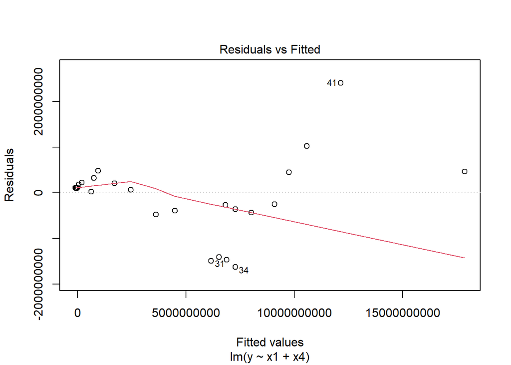

```r
plot(model1,1)
```

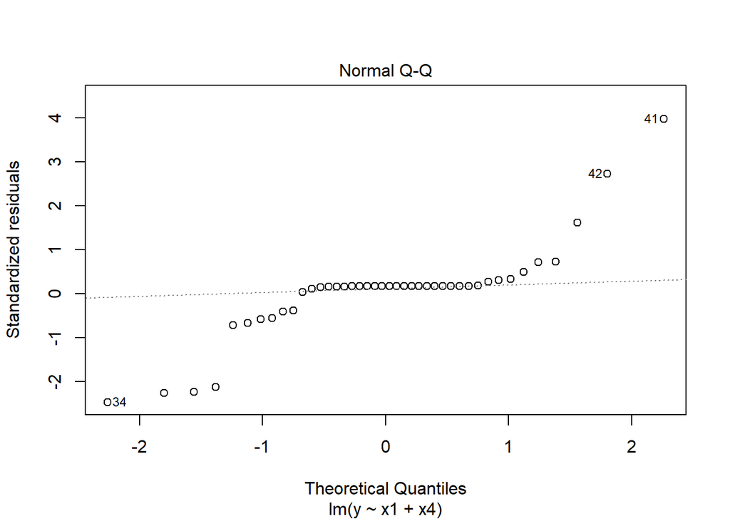

```r
plot(model1,2)
```

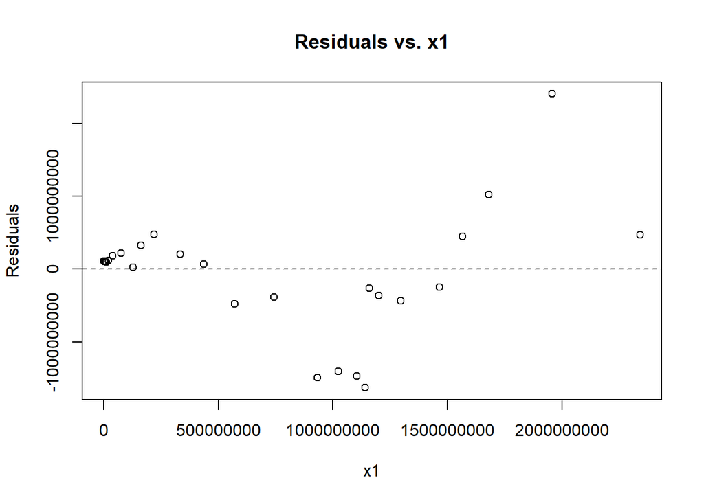

```r
#We can also plot residuals vs. x1 and residuals vs. x4 as follows:
plot(x1, resid(model1), ylab="Residuals", xlab="x1", main="Residuals vs. x1")
abline(0, 0, lty=2)
```

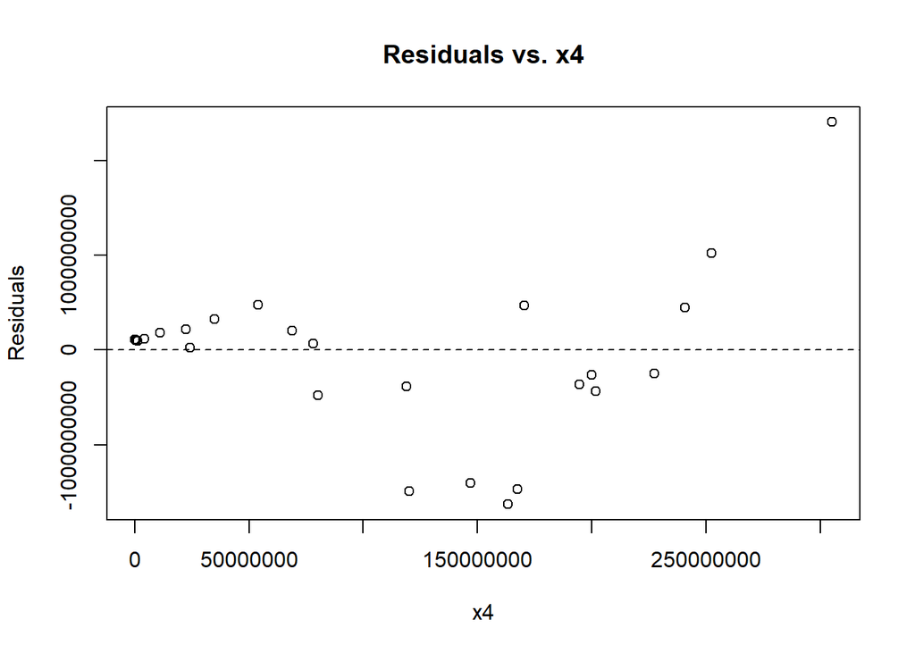

```r
plot(x4, resid(model1), ylab="Residuals", xlab="x4", main="Residuals vs. x4")
abline(0, 0, lty=2)
```

…

#### 3.3.2.9. Residuals Analysis

Residuals analysis was done in the Adequacy of the Regression Model part. Residual analysis graphs such as Residual versus x1(Current Expenditures), Residuals versus x4(Defence) and also interpretation about the Residuals analysis can be seen in the Adequacy of the Regression Model part …

```r
"ABOVE "
```

```
## [1] "ABOVE "
```

…

## 3.4. Trend Based Forecasting

Forecast analysis for Budget Expenditures has been made. Since the data is annual, it cannot be observed any seasonality. Only trend-based forecasting can be applied. Quadratic Trend and Linear Trends are applied and comparision of two are interpreted with R squared. All of Data Quadratic method is more useful than linear trend because of adjusted R squared are high …

```r
require(forecast)
#Write your codes here. Their results will appear after knitting the markdown file.
#Quadratic Trend
"FOR CURRENT EXPENDITURES"
```

```
## [1] "FOR CURRENT EXPENDITURES"
```

```r
ce.ts <- ts(data_22$CE, start = c(1), end = c(42), freq = 1)
ce.lm <- tslm(ce.ts ~ trend + I(trend^2))
summary(ce.lm)
```

```
##
## Call:
## tslm(formula = ce.ts ~ trend + I(trend^2))
##
## Residuals:
##        Min         1Q     Median         3Q        Max
## -166088625  -89048609   -5932131   80386057  276099850
##
## Coefficients:
##              Estimate Std. Error t value             Pr(>|t|)
## (Intercept) 219385166   51784597    4.24              0.00013 ***
## trend       -55667315    5554495  -10.02      0.0000000000024 ***
## I(trend^2)    2371442     125261   18.93 < 0.0000000000000002 ***
## ---
## Signif. codes:  0 '***' 0.001 '**' 0.01 '*' 0.05 '.' 0.1 ' ' 1
##
## Residual standard error: 107000000 on 39 degrees of freedom
## Multiple R-squared:  0.975,  Adjusted R-squared:  0.974
## F-statistic:  762 on 2 and 39 DF,  p-value: <0.0000000000000002
```

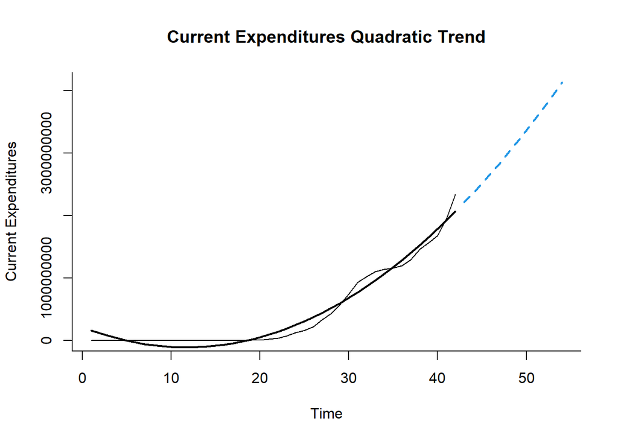

```r
ce.lm.pred <- forecast(ce.lm, h = 12, level = 0)
plot(ce.lm.pred, ylab = "Current Expenditures", xlab = "Time", bty = "l",
     main = "Current Expenditures Quadratic Trend", flty = 2)
lines(ce.lm$fitted, lwd = 2)
```

```r
"LINEAR TREND WITH ASSUMPTION ABOUT TRAINING AND VALIDATION"
```

```
## [1] "LINEAR TREND WITH ASSUMPTION ABOUT TRAINING AND VALIDATION"
```

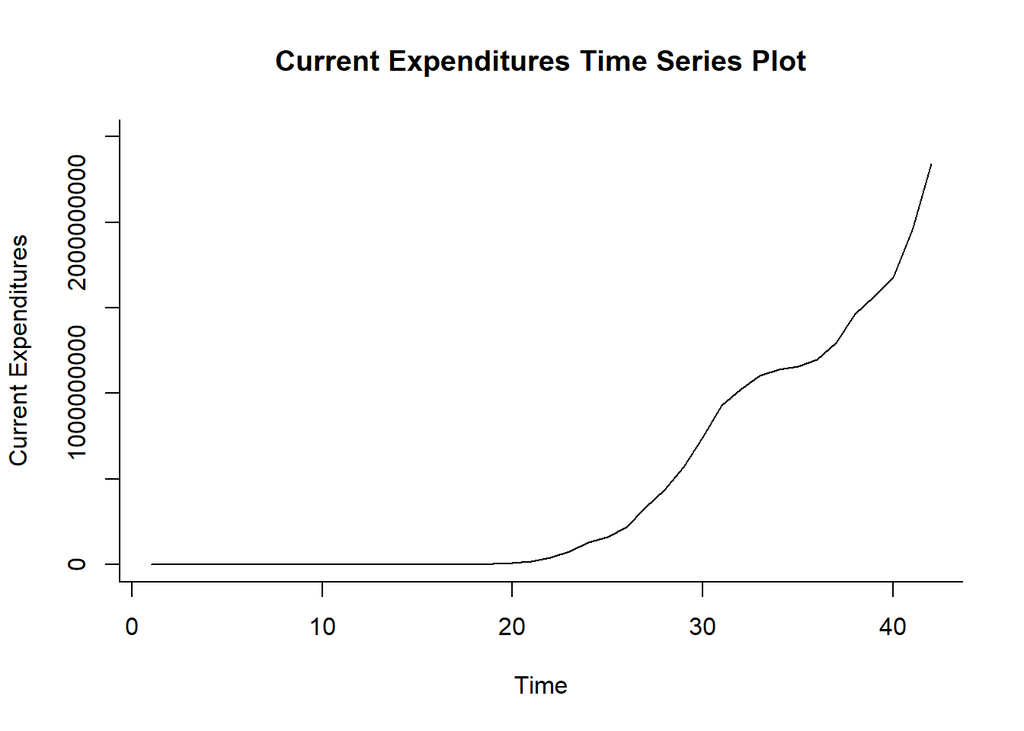

```r
ce.ts <- ts(data_22$CE, start = c(1), end = c(42))
plot(ce.ts, xlab = "Time", ylab = "Current Expenditures", main="Current Expenditures Time Series Plot",ylim = c(500, 2500000000), bty = "l")
```

```r
cetrain.ts <- window(ce.ts, start = 1, end = 37)
cevalid.ts <- window(ce.ts, start = 38, end = 42)

cetrain.lm <- tslm(cetrain.ts ~ trend)
summary(cetrain.lm)
```

```
##
## Call:
## tslm(formula = cetrain.ts ~ trend)
##
## Residuals:
##        Min         1Q     Median         3Q        Max
## -349415711 -224318073  -14681611  237722006  396898995
##
## Coefficients:
##               Estimate Std. Error t value      Pr(>|t|)
## (Intercept) -359333293   85243321   -4.22       0.00017 ***
## trend         34005534    3911232    8.69 0.00000000029 ***
## ---
## Signif. codes:  0 '***' 0.001 '**' 0.01 '*' 0.05 '.' 0.1 ' ' 1
##
## Residual standard error: 254000000 on 35 degrees of freedom
## Multiple R-squared:  0.684,  Adjusted R-squared:  0.674
## F-statistic: 75.6 on 1 and 35 DF,  p-value: 0.000000000289
```

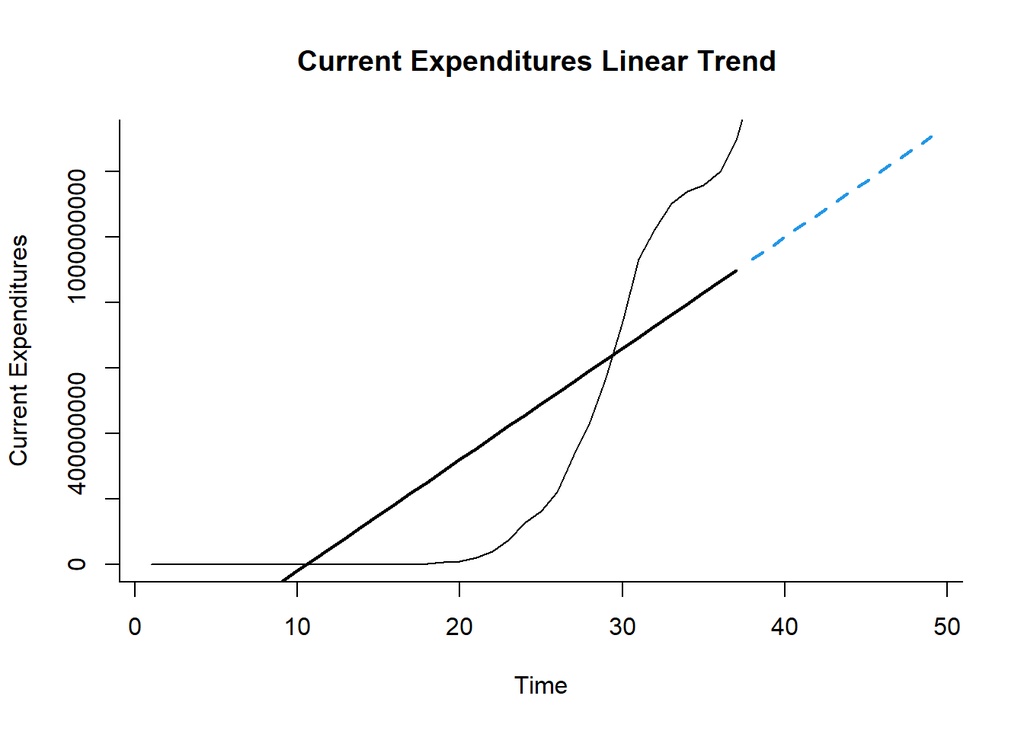

```r
cetrain.lm.pred <- forecast(cetrain.lm, h = 12, level = 0)
plot(cetrain.lm.pred, ylab = "Current Expenditures", xlab = "Time", bty = "l",
     main = "Current Expenditures Linear Trend ", flty = 2)
lines(cetrain.lm$fitted, lwd = 2)
lines(ce.ts)
```

```r
accuracy(cetrain.lm.pred$mean,cevalid.ts)
```

```
##                 ME      RMSE       MAE  MPE MAPE   ACF1 Theil's U
## Test set 800987695 845168379 800987695 43.3 43.3 0.3321     3.778
```

```r
"FOR PERSONNEL EXPENDITURES"
```

```
## [1] "FOR PERSONNEL EXPENDITURES"
```

```r
pe.ts <- ts(data_22$PE, start = c(1), end = c(42), freq = 1)
pe.lm <- tslm(pe.ts ~ trend + I(trend^2))
summary(pe.lm)
```

```
##
## Call:
## tslm(formula = pe.ts ~ trend + I(trend^2))
##
## Residuals:
##        Min         1Q     Median         3Q        Max
## -139983425  -71281555   -1405392   67621806  224446987
##
## Coefficients:
##              Estimate Std. Error t value             Pr(>|t|)
## (Intercept) 184900043   42354437    4.37       0.000090450713 ***
## trend       -46915335    4543002  -10.33       0.000000000001 ***
## I(trend^2)    1999271     102451   19.51 < 0.0000000000000002 ***
## ---
## Signif. codes:  0 '***' 0.001 '**' 0.01 '*' 0.05 '.' 0.1 ' ' 1
##
## Residual standard error: 87200000 on 39 degrees of freedom
## Multiple R-squared:  0.976,  Adjusted R-squared:  0.975
## F-statistic:  810 on 2 and 39 DF,  p-value: <0.0000000000000002
```

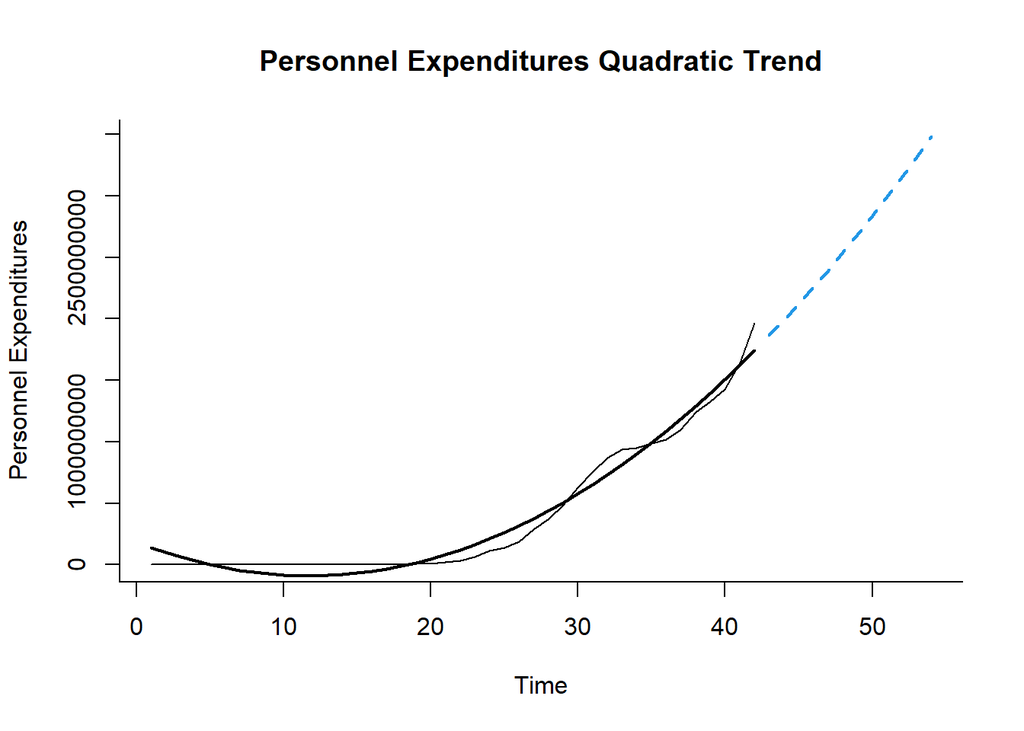

```r
pe.lm.pred <- forecast(pe.lm, h = 12, level = 0)
plot(pe.lm.pred, ylab = "Personnel Expenditures", xlab = "Time", bty = "l",
     main = "Personnel Expenditures Quadratic Trend", flty = 2)
lines(pe.lm$fitted, lwd = 2)
```

```r
"LINEAR TREND WITH ASSUMPTION ABOUT TRAINING AND VALIDATION"
```

```
## [1] "LINEAR TREND WITH ASSUMPTION ABOUT TRAINING AND VALIDATION"
```

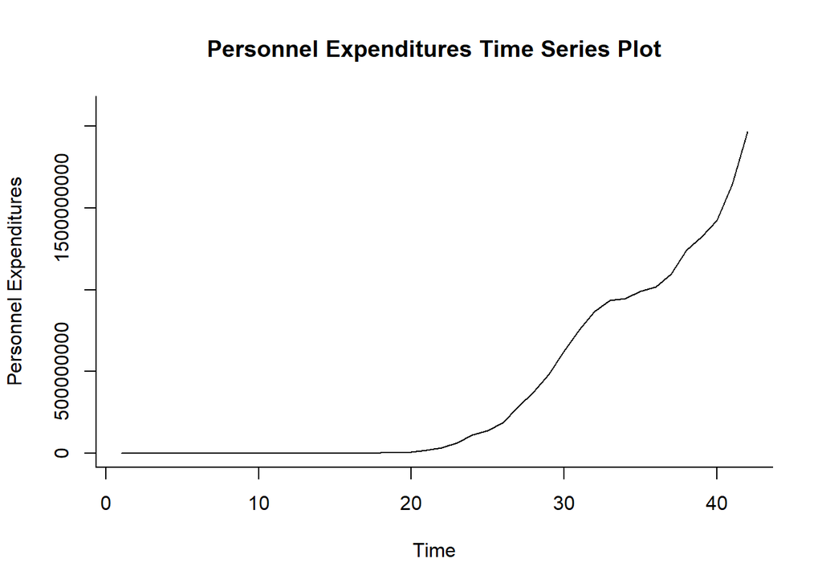

```r
pe.ts <- ts(data_22$PE, start = c(1), end = c(42))
plot(pe.ts, xlab = "Time", ylab = "Personnel Expenditures", main="Personnel Expenditures Time Series Plot",ylim = c(500, 2100000000), bty = "l")
```

```r
petrain.ts <- window(pe.ts, start = 1, end = 37)
pevalid.ts <- window(pe.ts, start = 38, end = 42)

petrain.lm <- tslm(petrain.ts ~ trend)
summary(petrain.lm)
```

```
##
## Call:
## tslm(formula = petrain.ts ~ trend)
##
## Residuals:
##        Min         1Q     Median         3Q        Max
## -293880164 -185519193  -12470346  188230375  339197940
##
## Coefficients:
##               Estimate Std. Error t value      Pr(>|t|)
## (Intercept) -302935713   71630623   -4.23       0.00016 ***
## trend         28676827    3286638    8.73 0.00000000026 ***
## ---
## Signif. codes:  0 '***' 0.001 '**' 0.01 '*' 0.05 '.' 0.1 ' ' 1
##
## Residual standard error: 213000000 on 35 degrees of freedom
## Multiple R-squared:  0.685,  Adjusted R-squared:  0.676
## F-statistic: 76.1 on 1 and 35 DF,  p-value: 0.000000000265
```

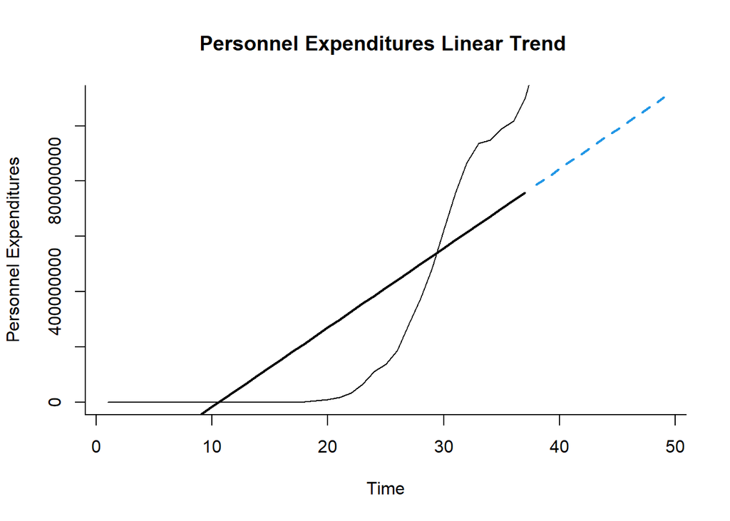

```r
petrain.lm.pred <- forecast(petrain.lm, h = 12, level = 0)
plot(petrain.lm.pred, ylab = "Personnel Expenditures", xlab = "Time", bty = "l",
     main = "Personnel Expenditures Linear Trend ", flty = 2)
lines(petrain.lm$fitted, lwd = 2)
lines(pe.ts)
```

```r
accuracy(petrain.lm.pred$mean,pevalid.ts)
```

```
##                 ME      RMSE       MAE   MPE  MAPE   ACF1 Theil's U
## Test set 676142782 711630563 676142782 43.38 43.38 0.3298     3.858
```

```r
"FOR OTHER CURRENT EXPENDITURES"
```

```
## [1] "FOR OTHER CURRENT EXPENDITURES"
```

```r
oce.ts <- ts(data_22$OCE, start = c(1), end = c(42), freq = 1)
oce.lm <- tslm(oce.ts ~ trend + I(trend^2))
summary(oce.lm)
```

```
##
## Call:
## tslm(formula = oce.ts ~ trend + I(trend^2))
##
## Residuals:
##       Min        1Q    Median        3Q       Max
## -26105200 -17855663   -913152  13883393  55714053
##
## Coefficients:
##             Estimate Std. Error t value             Pr(>|t|)
## (Intercept) 34485123    9928649    3.47               0.0013 **
## trend       -8751980    1064962   -8.22        0.00000000049 ***
## I(trend^2)    372172      24016   15.50 < 0.0000000000000002 ***
## ---
## Signif. codes:  0 '***' 0.001 '**' 0.01 '*' 0.05 '.' 0.1 ' ' 1
##
## Residual standard error: 20400000 on 39 degrees of freedom
## Multiple R-squared:  0.963,  Adjusted R-squared:  0.961
## F-statistic:  509 on 2 and 39 DF,  p-value: <0.0000000000000002
```

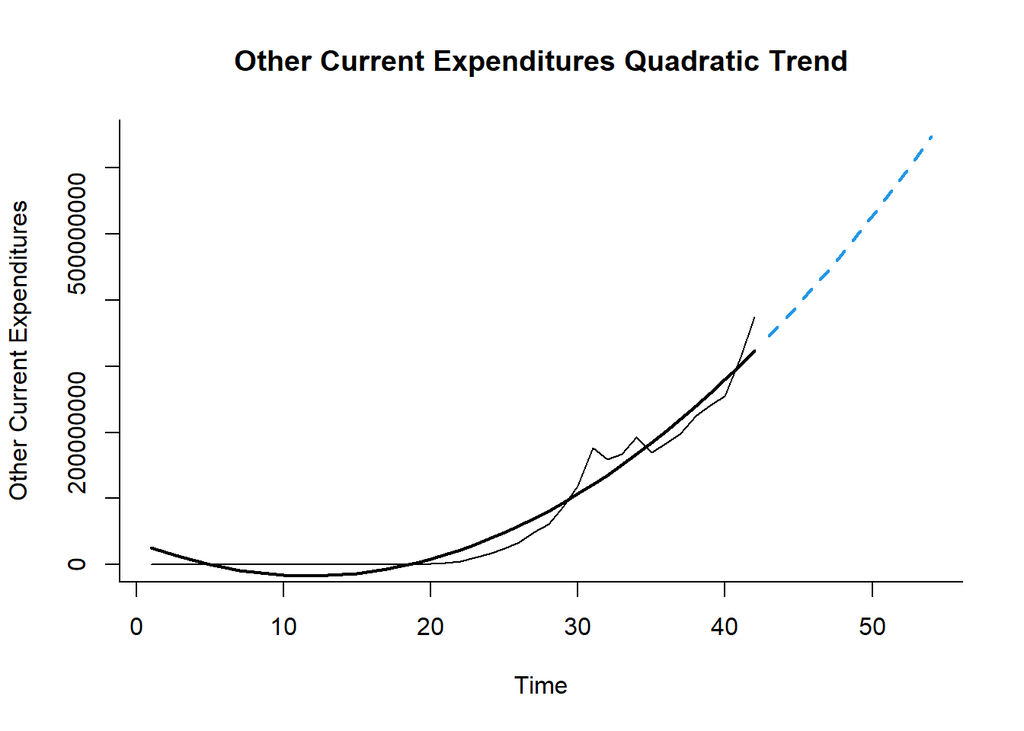

```r
oce.lm.pred <- forecast(oce.lm, h = 12, level = 0)
plot(oce.lm.pred, ylab = "Other Current Expenditures", xlab = "Time", bty = "l",
     main = "Other Current Expenditures Quadratic Trend", flty = 2)
lines(oce.lm$fitted, lwd = 2)
```

```r
"LINEAR TREND WITH ASSUMPTION ABOUT TRAINING AND VALIDATION"
```

```
## [1] "LINEAR TREND WITH ASSUMPTION ABOUT TRAINING AND VALIDATION"
```

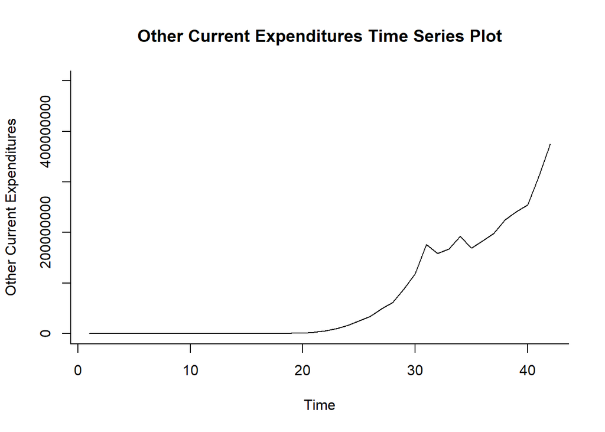

```r
oce.ts <- ts(data_22$OCE, start = c(1), end = c(42))
plot(oce.ts, xlab = "Time", ylab = "Other Current Expenditures", main="Other Current Expenditures Time Series Plot",ylim = c(100, 500000000), bty = "l")
```

```r
ocetrain.ts <- window(oce.ts, start = 1, end = 37)
ocevalid.ts <- window(oce.ts, start = 38, end = 42)

ocetrain.lm <- tslm(ocetrain.ts ~ trend)
summary(ocetrain.lm)
```

```
##
## Call:
## tslm(formula = ocetrain.ts ~ trend)
##
## Residuals:
##       Min        1Q    Median        3Q       Max
## -56003271 -38798880  -2211265  39460119  67870042
##
## Coefficients:
##              Estimate Std. Error t value      Pr(>|t|)
## (Intercept) -56397580   13809229   -4.08       0.00024 ***
## trend         5328706     633611    8.41 0.00000000064 ***
## ---
## Signif. codes:  0 '***' 0.001 '**' 0.01 '*' 0.05 '.' 0.1 ' ' 1
##
## Residual standard error: 41200000 on 35 degrees of freedom
## Multiple R-squared:  0.669,  Adjusted R-squared:  0.66
## F-statistic: 70.7 on 1 and 35 DF,  p-value: 0.00000000064
```

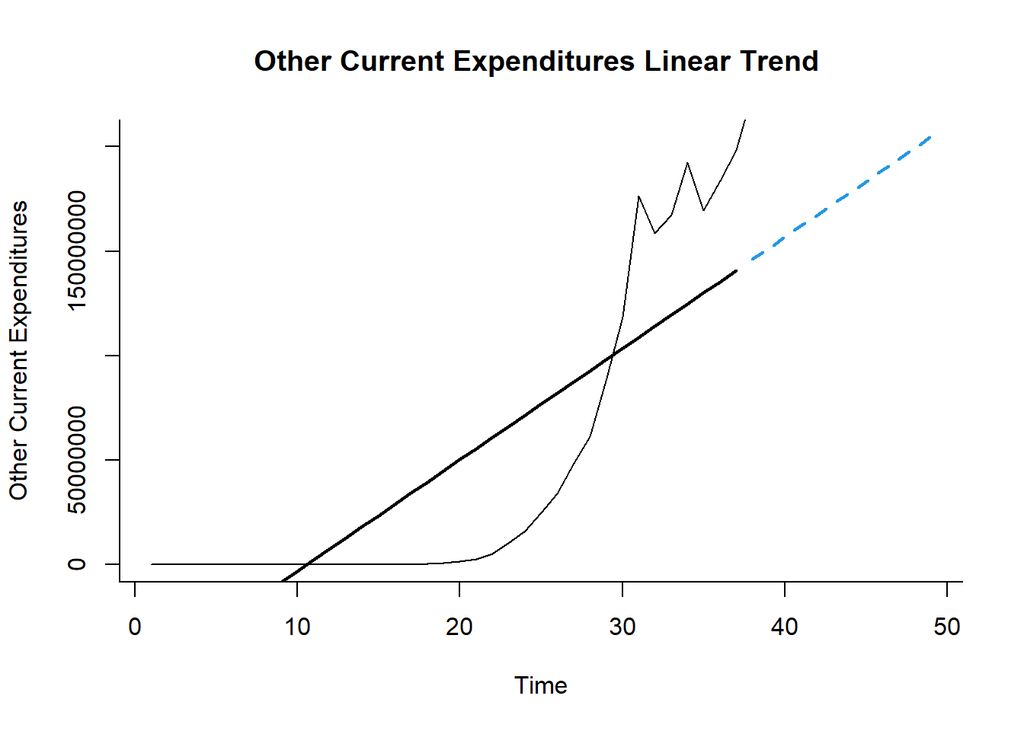

```r
ocetrain.lm.pred <- forecast(ocetrain.lm, h = 12, level = 0)
plot(ocetrain.lm.pred, ylab = "Other Current Expenditures", xlab = "Time", bty = "l",
     main = "Other Current Expenditures Linear Trend ", flty = 2)
lines(ocetrain.lm$fitted, lwd = 2)
lines(oce.ts)
```

```r
accuracy(ocetrain.lm.pred$mean,ocevalid.ts)
```

```
##                 ME      RMSE       MAE   MPE  MAPE   ACF1 Theil's U
## Test set 124844912 133708414 124844912 42.85 42.85 0.3387     3.344
```

```r
"FOR DEFENCE"
```

```
## [1] "FOR DEFENCE"
```

```r
d.ts <- ts(data_22$D, start = c(1), end = c(42), freq = 1)
d.lm <- tslm(d.ts ~ trend + I(trend^2))
summary(d.lm)
```

```
##
## Call:
## tslm(formula = d.ts ~ trend + I(trend^2))
##
## Residuals:
##        Min         1Q     Median         3Q        Max
## -110086618   -8071169    4307412   10228024   42508025
##
## Coefficients:
##             Estimate Std. Error t value         Pr(>|t|)
## (Intercept) 17971342   11161067    1.61             0.12
## trend       -5696346    1197153   -4.76 0.00002677447220 ***
## I(trend^2)    284502      26997   10.54 0.00000000000057 ***
## ---
## Signif. codes:  0 '***' 0.001 '**' 0.01 '*' 0.05 '.' 0.1 ' ' 1
##
## Residual standard error: 23000000 on 39 degrees of freedom
## Multiple R-squared:  0.94,   Adjusted R-squared:  0.937
## F-statistic:  305 on 2 and 39 DF,  p-value: <0.0000000000000002
```

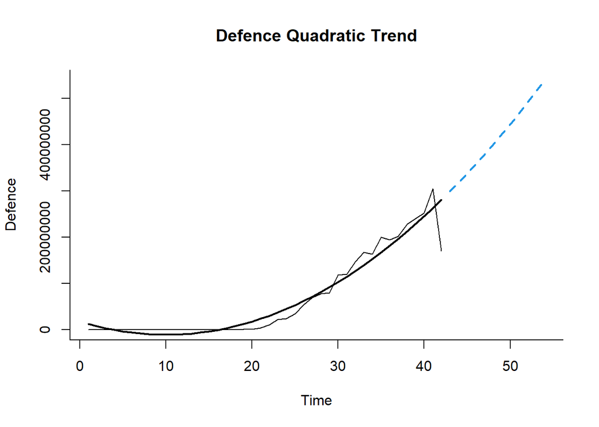

```r
d.lm.pred <- forecast(d.lm, h = 12, level = 0)
plot(d.lm.pred, ylab = "Defence", xlab = "Time", bty = "l",main = "Defence Quadratic Trend", flty = 2)
lines(d.lm$fitted, lwd = 2)
```

```r
"LINEAR TREND WITH ASSUMPTION ABOUT TRAINING AND VALIDATION"
```

```
## [1] "LINEAR TREND WITH ASSUMPTION ABOUT TRAINING AND VALIDATION"
```

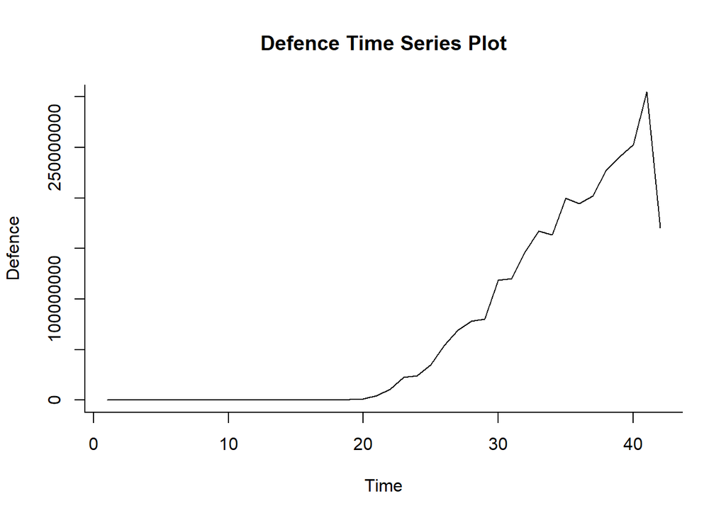

```r
d.ts <- ts(data_22$D, start = c(1), end = c(42))
plot(d.ts, xlab = "Time", ylab = "Defence", main="Defence Time Series Plot",ylim = c(100, 300000000), bty = "l")
```

```r
dtrain.ts <- window(d.ts, start = 1, end = 37)
dvalid.ts <- window(d.ts, start = 38, end = 42)

dtrain.lm <- tslm(dtrain.ts ~ trend)
summary(dtrain.lm)
```

```
##
## Call:
## tslm(formula = dtrain.ts ~ trend)
##
## Residuals:
##       Min        1Q    Median        3Q       Max
## -52106422 -29692341  -3115581  31741139  68914646
##
## Coefficients:
##              Estimate Std. Error t value       Pr(>|t|)
## (Intercept) -55519287   12510460   -4.44 0.000086478335 ***
## trend         5330986     574019    9.29 0.000000000057 ***
## ---
## Signif. codes:  0 '***' 0.001 '**' 0.01 '*' 0.05 '.' 0.1 ' ' 1
##
## Residual standard error: 37300000 on 35 degrees of freedom
## Multiple R-squared:  0.711,  Adjusted R-squared:  0.703
## F-statistic: 86.3 on 1 and 35 DF,  p-value: 0.0000000000566
```

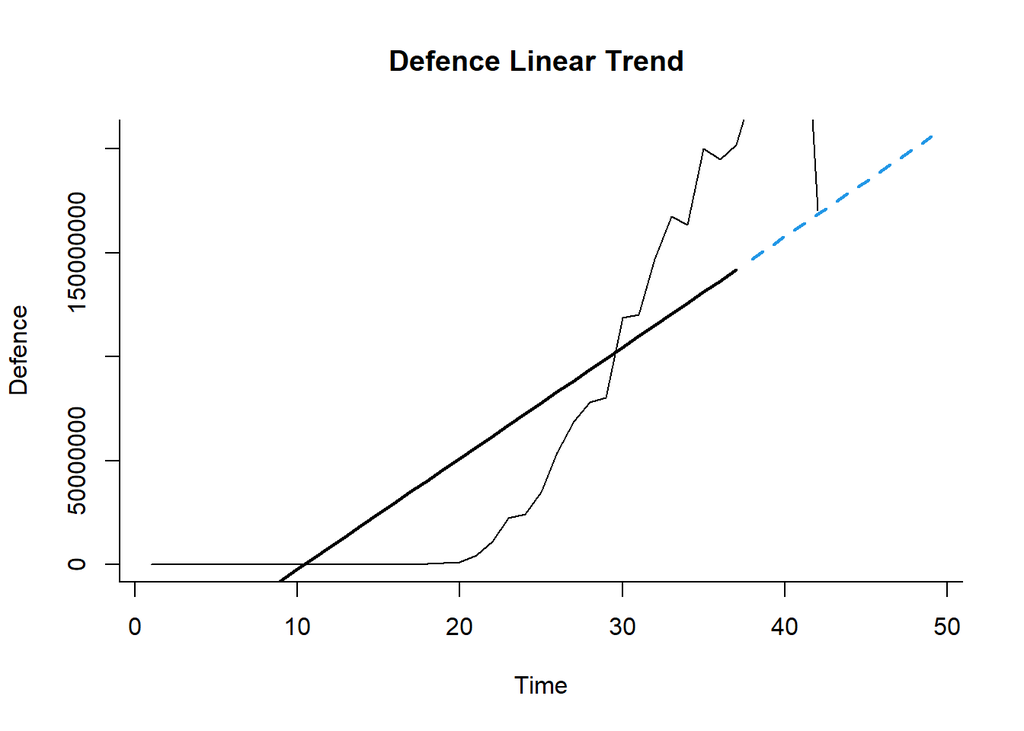

```r
dtrain.lm.pred <- forecast(dtrain.lm, h = 12, level = 0)
plot(dtrain.lm.pred, ylab = "Defence", xlab = "Time", bty = "l",
     main = "Defence Linear Trend ", flty = 2)
lines(dtrain.lm$fitted, lwd = 2)
lines(d.ts)
```

```r
accuracy(dtrain.lm.pred$mean,dvalid.ts)
```

```
##                ME     RMSE      MAE   MPE  MAPE    ACF1 Theil's U
## Test set 81579451 93249849 81579451 31.49 31.49 -0.3855     1.597
```

```r
"FOR GNP"
```

```
## [1] "FOR GNP"
```

```r
g.ts <- ts(data_22$GNP, start = c(1), end = c(42), freq = 1)
g.lm <- tslm(g.ts ~ trend + I(trend^2))
summary(g.lm)
```

```
##
## Call:
## tslm(formula = g.ts ~ trend + I(trend^2))
##
## Residuals:
##         Min          1Q      Median          3Q         Max
## -1581748970  -580246715  -188428931   632559395  4568965913
##
## Coefficients:
##               Estimate Std. Error t value             Pr(>|t|)
## (Intercept) 2020432936  530384790    3.81              0.00048 ***
## trend       -456200462   56889884   -8.02        0.00000000089 ***
## I(trend^2)    17520306    1282940   13.66 < 0.0000000000000002 ***
## ---
## Signif. codes:  0 '***' 0.001 '**' 0.01 '*' 0.05 '.' 0.1 ' ' 1
##
## Residual standard error: 1090000000 on 39 degrees of freedom
## Multiple R-squared:  0.943,  Adjusted R-squared:  0.94
## F-statistic:  322 on 2 and 39 DF,  p-value: <0.0000000000000002
```

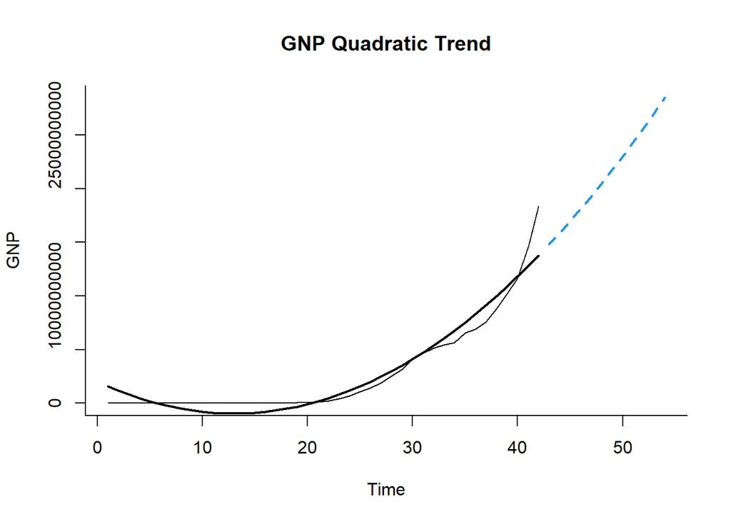

```r
g.lm.pred <- forecast(g.lm, h = 12, level = 0)
plot(g.lm.pred, ylab = "GNP", xlab = "Time", bty = "l",main = "GNP Quadratic Trend", flty = 2)
lines(g.lm$fitted, lwd = 2)
```

```r
"LINEAR TREND WITH ASSUMPTION ABOUT TRAINING AND VALIDATION"
```

```
## [1] "LINEAR TREND WITH ASSUMPTION ABOUT TRAINING AND VALIDATION"
```

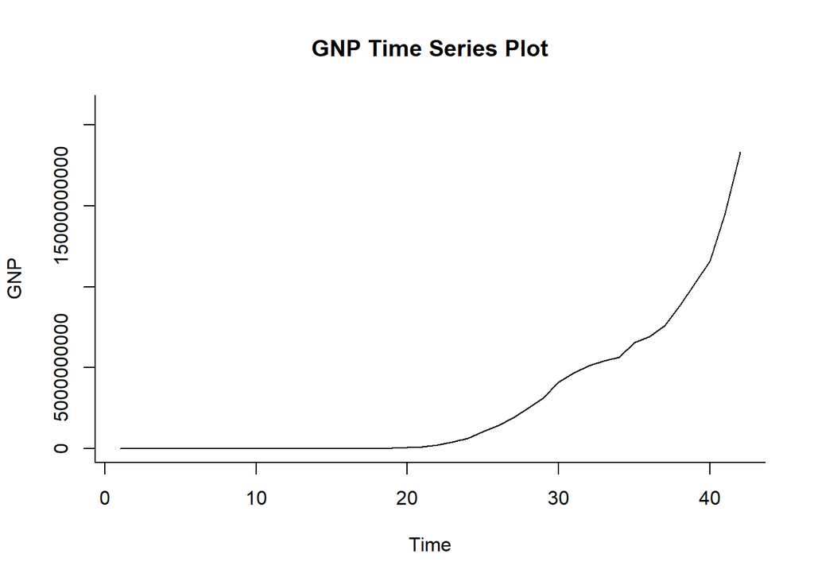

```r
g.ts <- ts(data_22$GNP, start = c(1), end = c(42))
plot(g.ts, xlab = "Time", ylab = "GNP", main="GNP Time Series Plot",ylim = c(3500, 21000000000), bty = "l")
```

```r
gtrain.ts <- window(g.ts, start = 1, end = 37)
gvalid.ts <- window(g.ts, start = 38, end = 42)

gtrain.lm <- tslm(gtrain.ts ~ trend)
summary(gtrain.lm)
```

```
##
## Call:
## tslm(formula = gtrain.ts ~ trend)
##
## Residuals:
##         Min          1Q      Median          3Q         Max
## -1888938877 -1181124492   -79833674  1170411078  2698194439
##
## Coefficients:
##                Estimate  Std. Error t value     Pr(>|t|)
## (Intercept) -1951105935   455950685   -4.28      0.00014 ***
## trend         184657156    20920452    8.83 0.0000000002 ***
## ---
## Signif. codes:  0 '***' 0.001 '**' 0.01 '*' 0.05 '.' 0.1 ' ' 1
##
## Residual standard error: 1360000000 on 35 degrees of freedom
## Multiple R-squared:  0.69,   Adjusted R-squared:  0.681
## F-statistic: 77.9 on 1 and 35 DF,  p-value: 0.0000000002
```

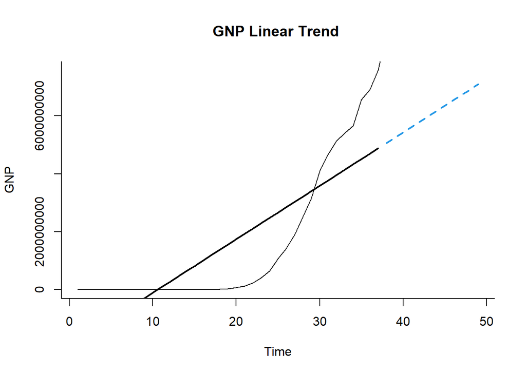

```r
gtrain.lm.pred <- forecast(gtrain.lm, h = 12, level = 0)
plot(gtrain.lm.pred, ylab = "GNP", xlab = "Time", bty = "l",
     main = "GNP Linear Trend ", flty = 2)
lines(gtrain.lm$fitted, lwd = 2)
lines(g.ts)
```

```r
accuracy(gtrain.lm.pred$mean,gvalid.ts)
```

```
##                  ME       RMSE        MAE   MPE  MAPE   ACF1 Theil's U
## Test set 7273447880 7920995491 7273447880 54.83 54.83 0.3564     3.395
```